# [Neural Networks]Assignment 1

r08454007 王苡蓁

2020/4/3

### 1. Write a vector equation that represents the above scalar equation in vector form. That is: a=?

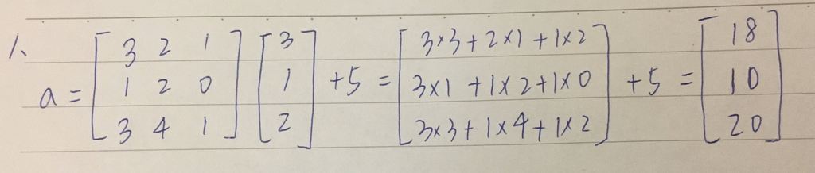

```r
#by R code
b<-c(3,1,2)
  dim(b)<-c(3,1)
c<-matrix(c(3,1,3,2,2,4,1,0,1),nrow=3, ncol=3)
a=c%*%b+5
print(a)
```

```
##      [,1]
## [1,]   18
## [2,]   10
## [3,]   20
```

### 2. Given all of the above data and a vector d (3x1), what would be the vector form of the scalar equation?

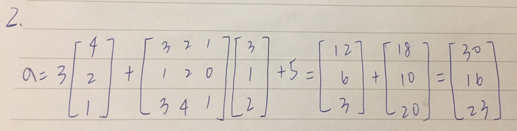

```r
#by R code
b<-c(3,1,2)
  dim(b)<-c(3,1)
c<-matrix(c(3,1,3,2,2,4,1,0,1),nrow=3, ncol=3)
d<-c(4,2,1)
  dim(d)<-c(3,1)

a=3*d+c%*%b+5
print(a)
```

```
##      [,1]
## [1,]   30
## [2,]   16
## [3,]   23
```

### 3. Which of the following !!! is/are not computable? Why? What’s the difference between (c) and (d)?

> (B)和(D)是無法計算的。矩陣要行列的個數都相同才可以相加，在(B)選項中，c是3x3矩陣而d是3x1，不一樣所以無法相加。

> 而矩陣的乘法，矩陣必須滿足A矩陣的“行數”等於B矩陣的“列數”才可以相乘。(D)選項中的b行數是3，d的列數是1，不一樣所以無法相加。

> (C)和(D)的差別在於$d^{t}$，是d的trandspose，原本的d是3x1矩陣，轉置之後變成1x3的矩陣。

```r
b<-c(3,1,2)
  dim(b)<-c(3,1)
c<-matrix(c(3,1,3,2,2,4,1,0,1),nrow=3, ncol=3)
d<-c(4,2,1)
  dim(d)<-c(3,1)

t=t(d)
A=c/2
#B=c+d
C=b%*%t
#D=b%*%d
E=c%*%(b+d)

print(A)
```

```
##      [,1] [,2] [,3]
## [1,]  1.5    1  0.5
## [2,]  0.5    1  0.0
## [3,]  1.5    2  0.5
```

```r
print(C)
```

```
##      [,1] [,2] [,3]
## [1,]   12    6    3
## [2,]    4    2    1
## [3,]    8    4    2
```

```r
print(E)
```

```
##      [,1]
## [1,]   30
## [2,]   13
## [3,]   36
```

### 4. Using R, compute matrix G = E•F and matrix H = F •E.Compare the two matrices G and H. What happens and why? Is this true for all values of matrices E and F? If not why?

> G和H矩陣的個各數值一模一樣，表示E*F=F*E。因為E和F都是diagonal matrix，也就是除了對角線其他數值皆為0的矩陣。而兩個diagonal matrix的乘法就是兩兩對角線的數值相乘，所以E和F前後交換結果也相同。其他的矩陣相乘前後交換是會影響結果的。

```r
E<-matrix(c(1,0,0,0,2,0,0,0,1),nrow=3, ncol=3)
F<-matrix(c(3,0,0,0,4,0,0,0,1),nrow=3, ncol=3)
G=E*F
H=F*E

print(G)
```

```
##      [,1] [,2] [,3]
## [1,]    3    0    0
## [2,]    0    8    0
## [3,]    0    0    1
```

```r
print(H)
```

```
##      [,1] [,2] [,3]
## [1,]    3    0    0
## [2,]    0    8    0
## [3,]    0    0    1
```

### 5. Given a vector v (3x1),compute vector u (3x1) given by:$u=1/(1+e^{-v})$

```r
v<-c(3,0,1)
dim(v)<-c(3,1)
u=1/(1+exp(-v))
u
```

```
##           [,1]
## [1,] 0.9525741
## [2,] 0.5000000
## [3,] 0.7310586
```